# Cálculo com Python

Nesta quarta parte do curso vamos estudar como usar o [Python](https://www.python.org/) para calcular integrais de funções de uma variável.

## 4 - Integração

Vamos aprender a usar a biblioteca [Python](https://www.python.org/) de matemática simbólica [Sympy](http://www.sympy.org) para computar:

- **integrais indefinidas**
- **integrais definidas**
- **computar áreas**

Começamos carrendo a biblioteca [Sympy](http://www.sympy.org):

```python
from sympy import *
init_printing()
var('x,y')
```

$$\left ( x, \quad y\right )$$

Para fixar as ideias, vamos continuar trabalhando com a função:

$f(x) = (x^3 - 3x + 2)e^{-x/4} - 1$.

```python
f = Lambda(x, (x**3 - 3*x + 2)*exp(-x/4) - 1)
f
```

$$\left( x \mapsto \left(x^{3} - 3 x + 2\right) e^{- \frac{x}{4}} - 1 \right)$$

### Integrais indefinidas

Vamos ver como podemos usar o [Sympy](https://www.sympy.org) para computarmos a integral da função $f$, i.e.

$\displaystyle \int f(x)\,dx$.

Para tanto, usamos a função [`integrate`](https://docs.sympy.org/latest/modules/integrals/integrals.html?highlight=integrate#sympy.integrals.integrate):

```python
integrate(f(x), x)
```

$$- x + \left(- 4 x^{3} - 48 x^{2} - 372 x - 1496\right) e^{- \frac{x}{4}}$$

#### Exercício:

Sendo $g(x) = x^2 + \frac{1}{2}$ calcule $\int g(x)\,dx$.

```python
#digite sua resolução aqui!
```

### Integrais definidas

Aqui, vamos ver como computar integrais definidas usando a biblioteca [Sympy](https://www.sympy.org). Para tanto, podemos usar a mesma função [`integrate`](https://docs.sympy.org/latest/modules/integrals/integrals.html?highlight=integrate#sympy.integrals.integrate) empregada acima. Por exemplo, computamos:

$\displaystyle \int_{-1}^{1} f(x)\,dx$:

```python
integrate(f(x), (x, -1, 1))
```

$$- \frac{1920}{e^{\frac{1}{4}}} - 2 + 1168 e^{\frac{1}{4}}$$

Para obtermos o valor em representalção decimal, digitamos:

```python
N(Out[5])
```

$$2.44418319418471$$

### Cálculo de Áreas

Lembramos que podemos usar integrais para calcular a área sob o gráfico de uma função.

Por exemplo, vamos calcular a área determinada pelas retas $x=-1$, $x=1$, a curva $y = f(x)$ e a reta $y=0$. Primeiramente, vamos fazer o esboço desta região. Para tanto, faremos uso das funções [`plot`](https://docs.sympy.org/latest/modules/plotting.html?highlight=plot#module-sympy.plotting.plot) e [`plot_implicit`](https://docs.sympy.org/latest/modules/plotting.html?highlight=plot_implicit#sympy.plotting.plot_implicit.plot_implicit):

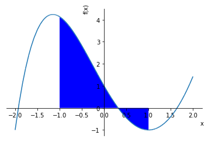

```python
%matplotlib inline
p = plot(f(x), (x, -2, 2), show=False)
q = plot_implicit(y<f(x), (x, -1, 1), (y, 0, 6), show=False)
p.extend(q)
q = plot_implicit(y>f(x), (x,-1,1), (y,-2,0), show=False)
p.extend(q)
p.show()
```

Agora, do cálculo, sabemos que a área definida acima é dada por:

$\displaystyle \int_{-1}^{1} |f(x)|\,dx = \int_{-1}^{x^{*}} f(x)\,dx - \int_{x^{*}}^1 f(x)\,dx$.

onde $x^*$ é a raiz de $f(x)$ contida no intervalo $(-1,1)$.

Usando a expressão da direita, podemos computar a área da seguinte forma:

```python
xstar = nsolve(f(x), x, 0.25) #encontra o zero x* de f
A = integrate(f(x), (x, -1, xstar)) - integrate(f(x), (x, xstar, 1))
N(A)
```

$$3.34298415940101$$

$\blacktriangleleft$

#### Exercício:

Calule a área da região determinada pelas retas $x=2$, $x=100$, $y=f(x)$ e a reta $y=0$.

```python
#digite a resolução aqui.
```

## Referências

- [1] Python Software Fundation (US): [www.python.org](https://www.python.org/)
- [2] Sympy - Python Library for Symbolic Mathematics: [www.sympy.org](http://www.sympy.org/)

## Quer aprender Python? Comece aqui!

- Codecademy - Lear to code: [www.codecademy.com](https://www.codecademy.com/catalog/language/python)
- Python Brasil: https://python.org.br/introducao/

## Ligações relacionadas

- [1] Sympy Gamma: [www.sympygamma.org](http://www.sympygamma.com/)
- [2] Sympy Live: [live.sympy.org](http://live.sympy.org/)

Criado: Out/2015 Última modificação: Out/2019

O texto acima está sob Licença [Creative Commons Atribuição-CompartilhaIgual 4.0 Internacional](http://creativecommons.org/licenses/by-sa/4.0/deed.pt_BR). Contato

**Erros? Sugestões?**

Clique aqui para informar erros ou deixar sujestões!